# PCA Introduction for Data Scholars Discovery

Evan Muzzall

2/15/2018

> NOTE: *see the .Rmd file for the code!*

# 1 Goal

Pretend you are a [bioarchaeologist for a day!](https://en.wikipedia.org/wiki/Bioarchaeology) You excavate skeletons from five famous archaeological sites: Çatalhöyük, Halstatt, Huaca Loro, Odai Yamamoto, and Shum Laka.

The data collection process usually involves collecting data of different types due to the complexities of archaeological sites:  
* Factor variables often reflect hard-to-quantify data such as characteristics of a burial (such as its location and style) and some biological information about the skeleton (e.g., sex estimation and health status).  
* Integers are often used to count the number of items placed in the burial, and often include religious/symbolic, practical, and luxury items.  
* Numeric data are often used to record measurements of individual bones of the skeleton.

Bioarchaeologists seek to use such data to make inferences about the living people of the past. This is challenging not only due to our [inherent biases](https://en.wikipedia.org/wiki/Archaeological_theory) when making such inferences, but also because analysis is hard since our data often consist of different types!

PCA and other [ordination methods](http://ordination.okstate.edu/) are important to investigate mixed datasets such as the toy one created below. We ask: how can PCA help us interpret these data so that we are able to gain some understanding of the variation of these variables across the five archaeological sites?

# 2 Generate toy data

```r
options(width=100)
dat
```

```
##             Site    Sex    Health Burial_location Depth Burial_items Ceramic_vessels Femur_length
## 1     Huaca Loro   Male   Average        Cemetery   110           10              10        480.1
## 2     Huaca Loro   Male      Poor          Temple   120            8              11        481.0
## 3     Huaca Loro Female Excellent          Temple   120            7              14        400.3
## 4     Huaca Loro   Male Excellent          Temple   100            4              15        482.9
## 5     Huaca Loro Female Excellent        Cemetery    80            6              13        405.7
## 6       Halstatt   Male   Average        Hillside    40            0               3        490.4
## 7       Halstatt Female   Average           Beach    40            0               4        440.1
## 8       Halstatt   Male   Average        Hillside    50            1               2        499.8
## 9       Halstatt Female   Average        Hillside    60            2               4        442.5
## 10      Halstatt   Male Excellent           Beach    40            5               2        502.1
## 11    Catalhoyuk   Male   Average          Shrine    80            3               2        460.5
## 12    Catalhoyuk   Male   Average          Basket    80            2               3        469.2
## 13    Catalhoyuk Female   Average          Basket    70            4               2        455.4
## 14    Catalhoyuk   Male   Average          Basket    80            4               5        462.1
## 15    Catalhoyuk Female   Average     Rockshelter    60            3               6        459.0
## 16 Odai Yamamoto   Male   Average          Temple   100           15               1        480.6
## 17 Odai Yamamoto   Male   Average          Temple   120           18               1        479.9
## 18 Odai Yamamoto Female   Average           Beach    90           12               1        420.4
## 19 Odai Yamamoto Female Excellent          Temple   100           12               1        422.9
## 20 Odai Yamamoto   Male      Poor           Beach    90           14               3        478.7
## 21     Shum Laka Female Excellent            Cave    20            1               1        470.1
## 22     Shum Laka Female Excellent          Shrine    10            2               1        469.2
## 23     Shum Laka Female Excellent     Rockshelter    20            0               0        473.4
## 24     Shum Laka Female Excellent            Cave    10            0               0        478.7
## 25     Shum Laka Female Excellent            Cave    10            0               0        471.0
```

**EXAMPLE WORKFLOW:**  
First scale the numeric data and visualize it with boxplots. Then, use the `princomp` R function to fit the model on the numeric data and view the scree plot, biplot, and scatterplot. Then, extract the first two principal component loadings to view variation along these axes.

# 3 Install + library necessary packages

```r
library(ggplot2) # ggplots
library(gridExtra) # panel ggplots
library(PCAmixdata) # PCA for mixed-data
library(psych) # summary stats
library(reshape2) # melt data for boxplots
library(rgl) # 3d plot
# see library(help = "base") to list all functions from any package
```

# 4 Scale the numeric variables

```r
# first create a subset named "numeric" that contains only the numeric variables
numeric <- dat[,c("Depth", "Burial_items", "Ceramic_vessels", "Femur_length")]
numeric
```

```
##    Depth Burial_items Ceramic_vessels Femur_length
## 1    110           10              10        480.1
## 2    120            8              11        481.0
## 3    120            7              14        400.3
## 4    100            4              15        482.9
## 5     80            6              13        405.7
## 6     40            0               3        490.4
## 7     40            0               4        440.1
## 8     50            1               2        499.8
## 9     60            2               4        442.5
## 10    40            5               2        502.1
## 11    80            3               2        460.5
## 12    80            2               3        469.2
## 13    70            4               2        455.4
## 14    80            4               5        462.1
## 15    60            3               6        459.0
## 16   100           15               1        480.6
## 17   120           18               1        479.9
## 18    90           12               1        420.4
## 19   100           12               1        422.9
## 20    90           14               3        478.7
## 21    20            1               1        470.1
## 22    10            2               1        469.2
## 23    20            0               0        473.4
## 24    10            0               0        478.7
## 25    10            0               0        471.0
```

```r
# then, scale the data
num <- data.frame(scale(numeric, center=TRUE, scale=TRUE))
num
```

```
##          Depth Burial_items Ceramic_vessels Femur_length
## 1   1.15021737    0.8795812      1.25573684   0.62825656
## 2   1.42407865    0.5036918      1.47224319   0.66140022
## 3   1.42407865    0.3157471      2.12176224  -2.31048162
## 4   0.87635609   -0.2480870      2.33826859   0.73137018
## 5   0.32863353    0.1278024      1.90525589  -2.11161964
## 6  -0.76681158   -0.9998658     -0.25980762   1.00756738
## 7  -0.76681158   -0.9998658     -0.04330127  -0.84479516
## 8  -0.49295030   -0.8119211     -0.47631397   1.35373453
## 9  -0.21908902   -0.6239764     -0.04330127  -0.75641206
## 10 -0.76681158   -0.0601423     -0.47631397   1.43843500
## 11  0.32863353   -0.4360317     -0.47631397  -0.09353878
## 12  0.32863353   -0.6239764     -0.25980762   0.22684996
## 13  0.05477226   -0.2480870     -0.47631397  -0.28135288
## 14  0.32863353   -0.2480870      0.17320508  -0.03461672
## 15 -0.21908902   -0.4360317      0.38971143  -0.14877822
## 16  0.87635609    1.8193046     -0.69282032   0.64666970
## 17  1.42407865    2.3831387     -0.69282032   0.62089130
## 18  0.60249481    1.2554705     -0.69282032  -1.57027313
## 19  0.87635609    1.2554705     -0.69282032  -1.47820740
## 20  0.60249481    1.6313599     -0.25980762   0.57669975
## 21 -1.31453414   -0.8119211     -0.69282032   0.25999363
## 22 -1.58839542   -0.6239764     -0.69282032   0.22684996
## 23 -1.31453414   -0.9998658     -0.90932667   0.38152040
## 24 -1.58839542   -0.9998658     -0.90932667   0.57669975
## 25 -1.58839542   -0.9998658     -0.90932667   0.29313729
```

# 5 Scaled data boxplots

Construct boxplots to see how the scaled numeric variables look

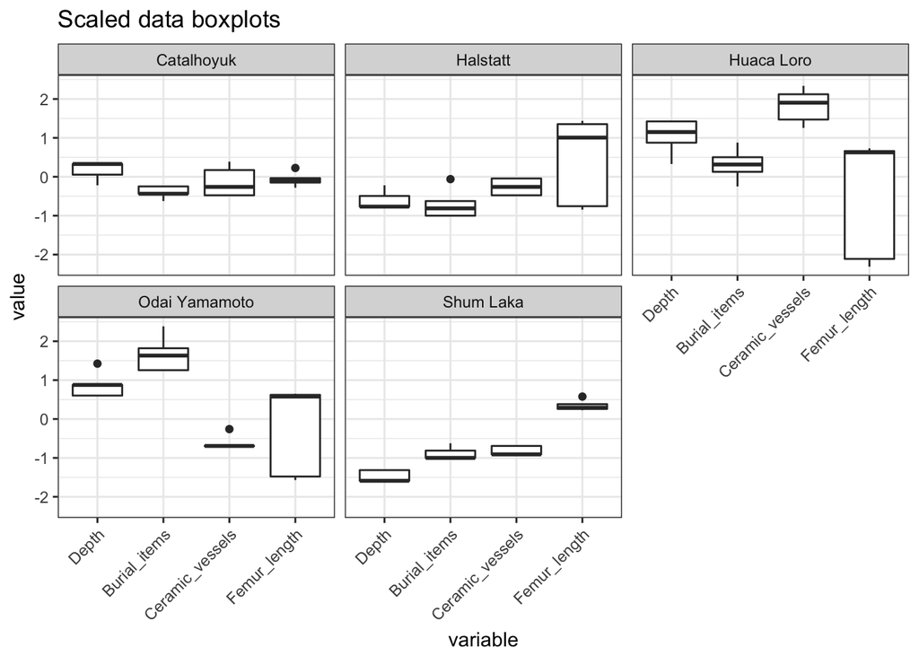

```r
boxplots
```

# 6 What is PCA?

- Powerful linear transformation technique to explore patterns in data and correlated variables.
- Distill variation across many variables onto a reduced feature space (e.g., a scatterplot) while maintaining the integrity of the data.

How to:  
1. Scale data  
2. Compute Eigenpairs (via eigendecomposition on covariance matrix or correlation matrix; singular value decomposition):  
2.1. Eigenvector - principal component; stored in projection matrix. Defines directions of the new feature space.  
2.2. Eigenvalue - explains magnitude of the Eigenvector; defines how much variance along each axis.  
3. Choose the eigenvectors *k* with largest eigenvalues  
4. Construct projection matrix *W*  
5. Use *W* to transform an original dataset *A* to the *k*-dimensional feature subspace named *Y*

Math stuff is not discussed today. However, check out [Jordan’s (1987) **An introduction to linear algebra in parallel distributed processing**](https://www.cs.cmu.edu/afs/cs/academic/class/15883-f15/readings/jordan-1986-ch9.pdf) and [Kolter and Do’s (2015) **Linear algebra review and reference**](http://www.cs.cmu.edu/~zkolter/course/15-884/linalg-review.pdf) to learn more.

# 7 `princomp` PCA

Now, fit the PCA model using the built-in `princomp` function (from the “stats” package). Check out the **screeplot, biplot, and scatterplot!**

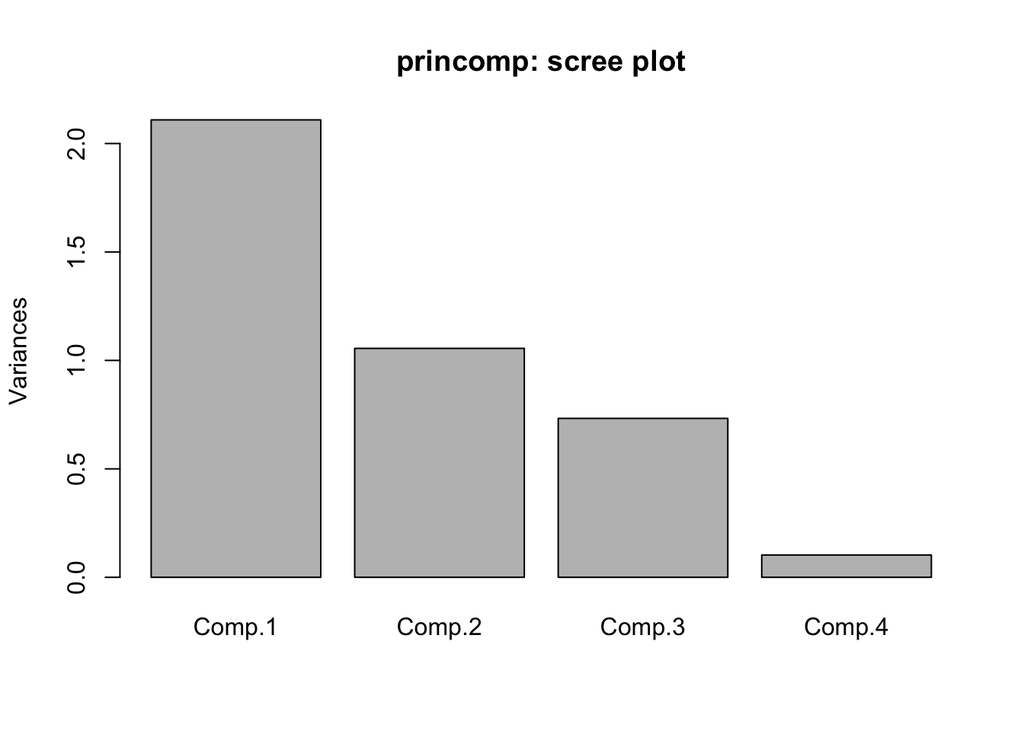

```r
plot(pca_princomp, main = "princomp: scree plot")
```

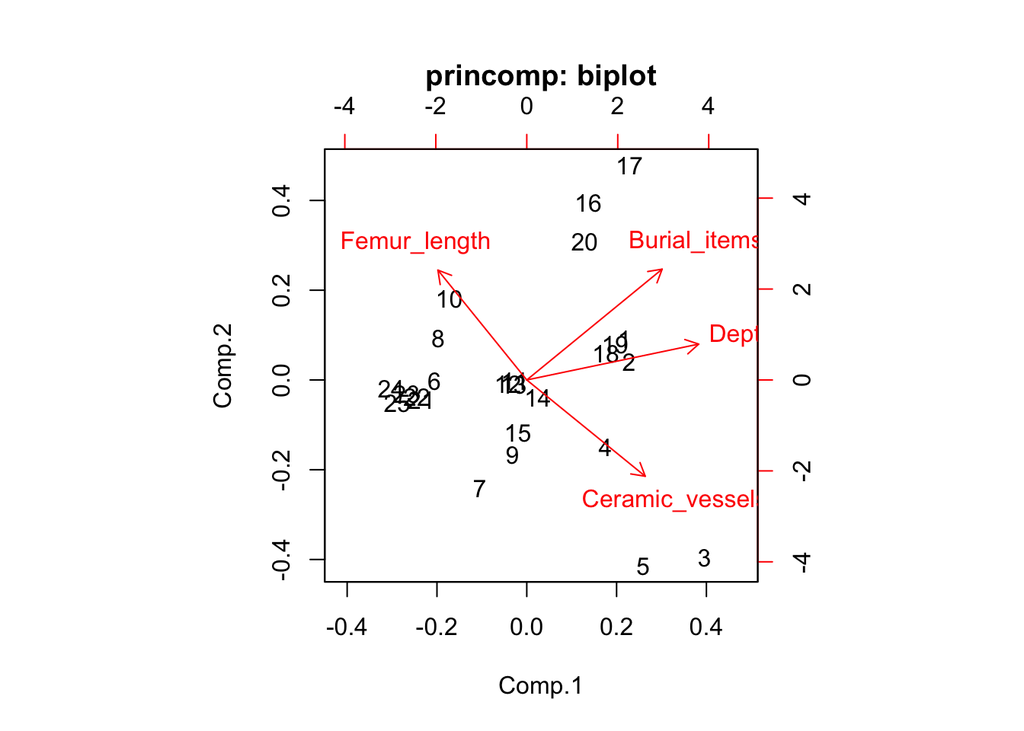

```r
biplot(pca_princomp, main = "princomp: biplot")
```

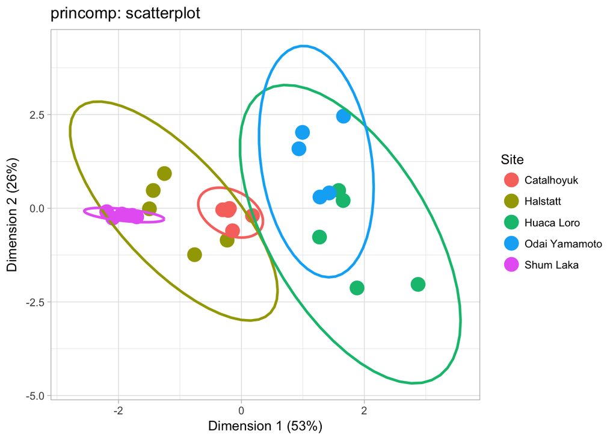

```r
pca_princomp_plot
```

# 8 `princomp` PCA - loadings

Now, extract the loadings

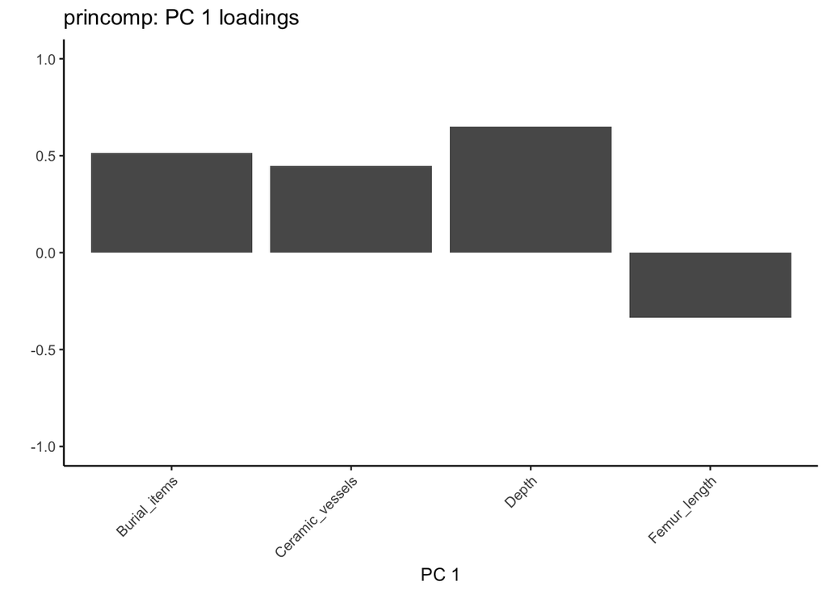

```r
pca_pc1
```

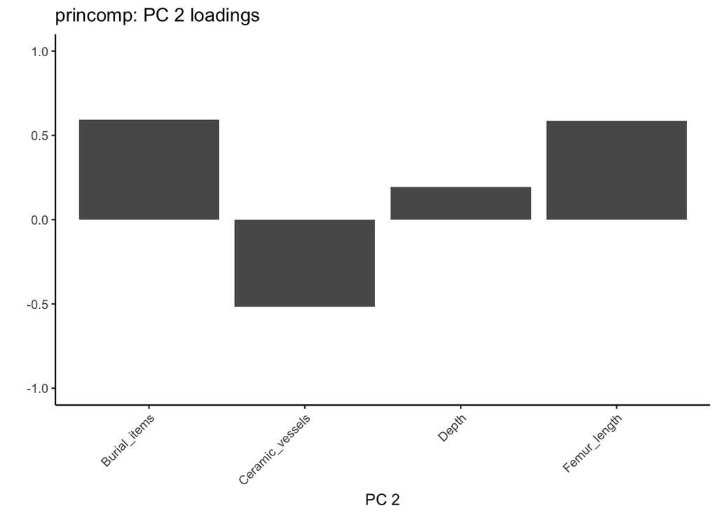

```r
pca_pc2
```

# 9 `princomp` PCA - loadings in 2D

Then you can view the loadings in two dimensions

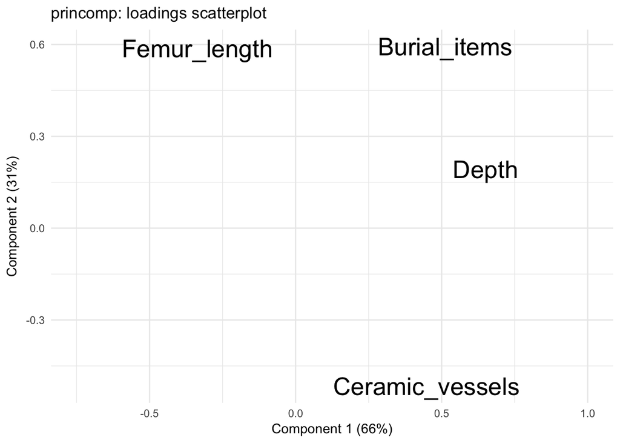

```r
pca_df_vars_plot
```

# 10 `PCAmix` PCA

`princomp` only performed PCA on the numeric variables. Let’s use the `PCAmix` function from the “PCAmixdata” package to include the factor variables as well:

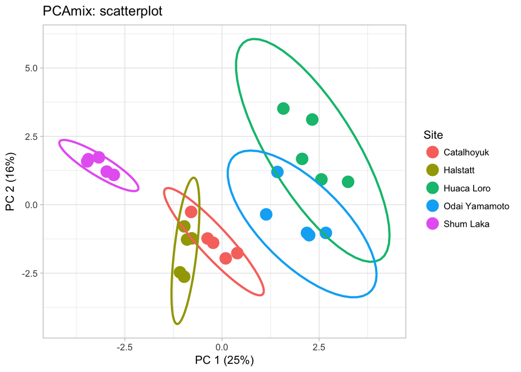

```r
pca_mix_plot
```

# 11 `PCAmix` PCA - loadings

Now, look at the loadings for PC PC 1 and PC 2 for the updated model:

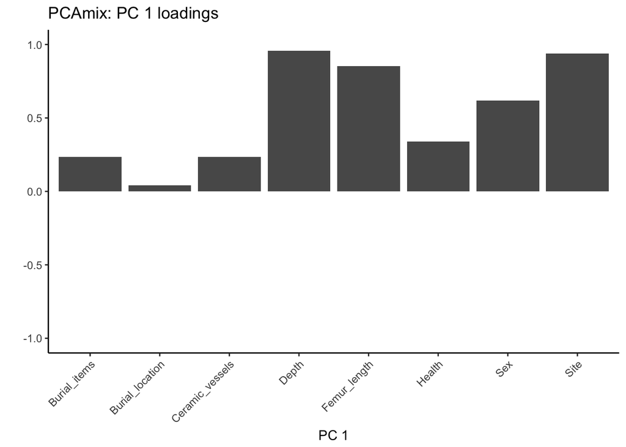

```r
pca_mix_pc1
```

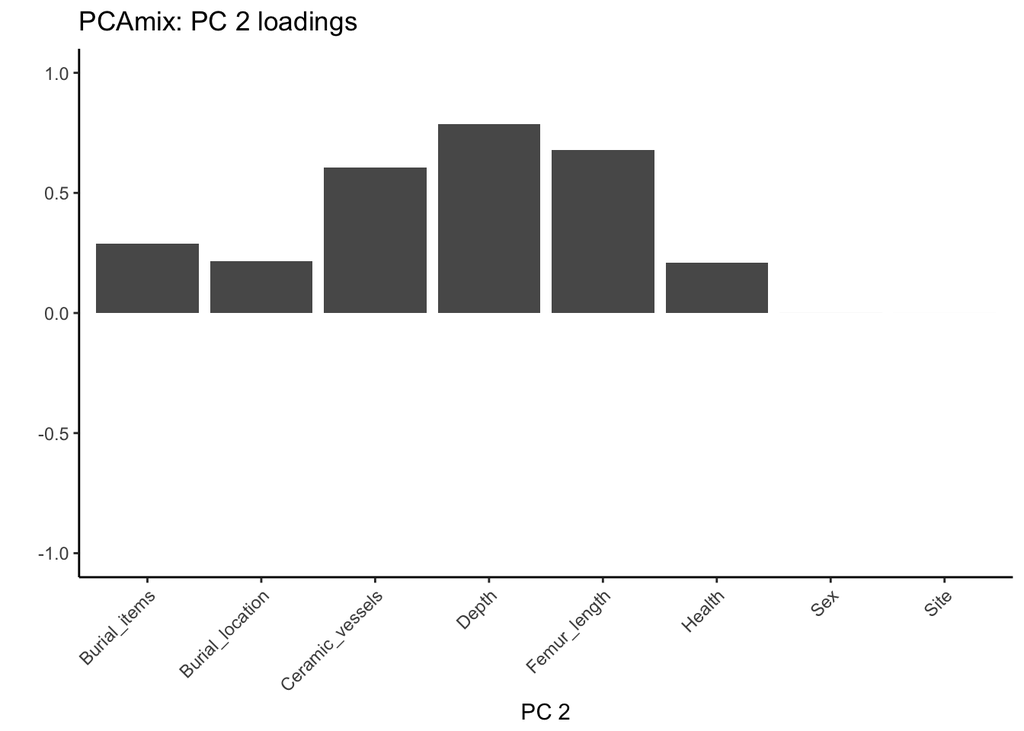

```r
pca_mix_pc2
```

# 12 `PCAmix` PCA - loadings in 2D

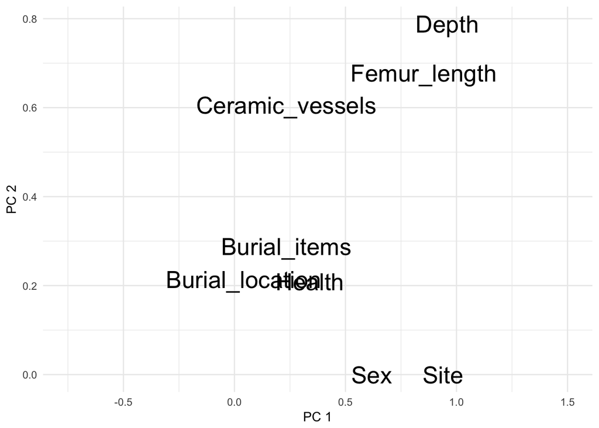

```r
pca_mix_df_vars_plot
```

# 13 `PCAmix` PCA - other visualizations

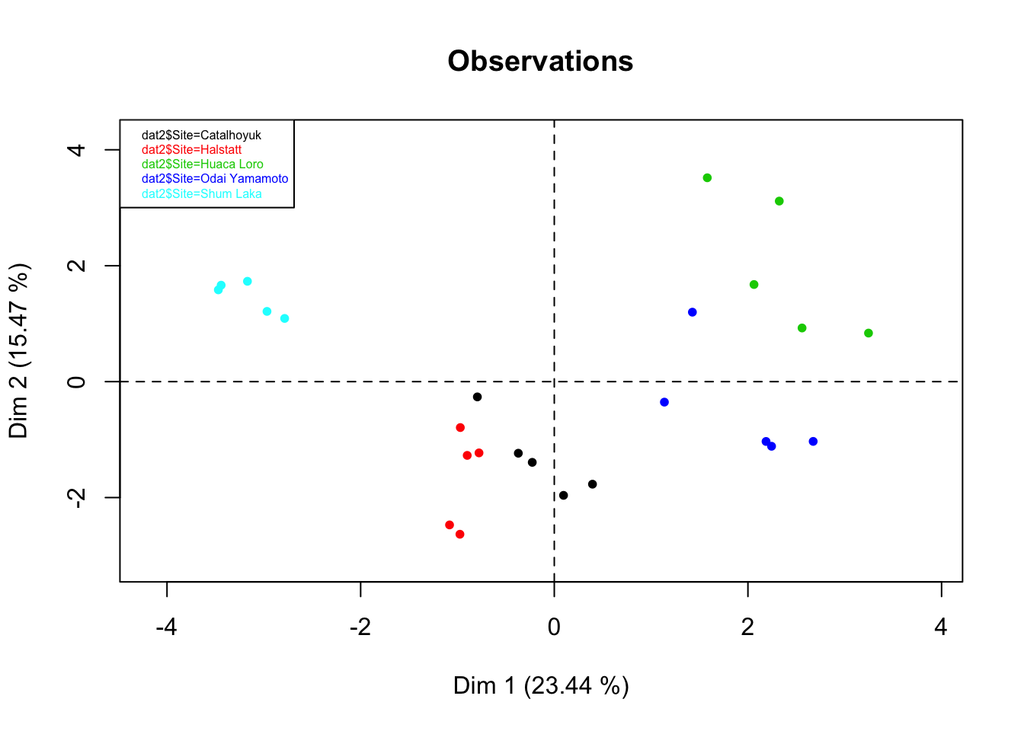

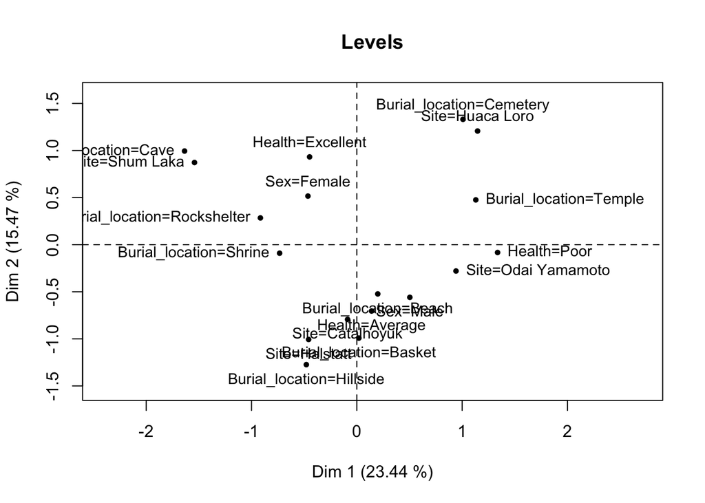

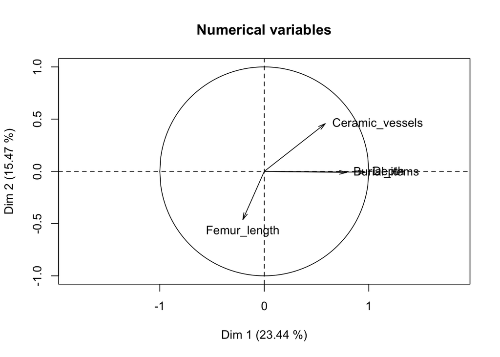

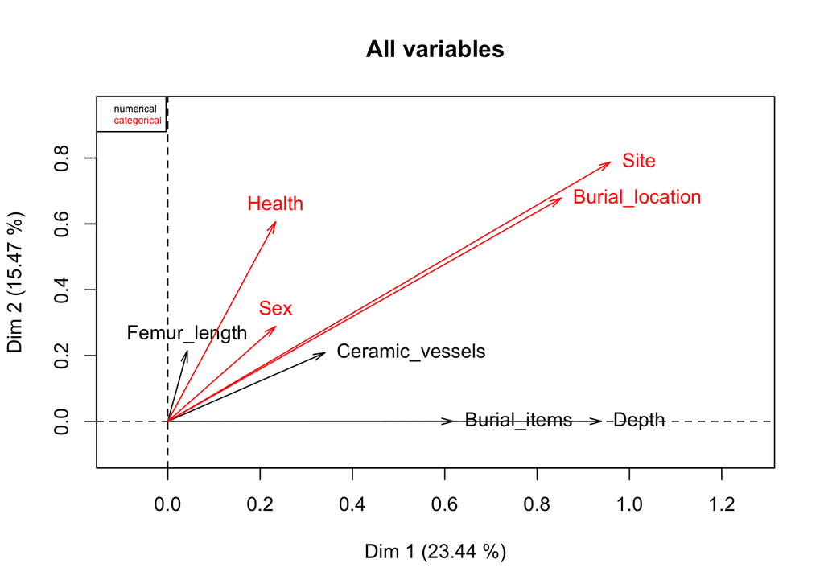

# 14 Quick NA handling

Use geometric mean scaling to circumvent missing data

# 15 interactive 3D scatterplot of geometrix mean scaled data with rgl’s `plot3d` function

Click and drag to move the plots around and zoom!

[interactive chart not shown]

# 16 PCA - basic machine learning example with `prcomp`

Let’s reproduce this example: [Stack Overflow - How to use R prcomp results for prediction?](https://stats.stackexchange.com/questions/72839/how-to-use-r-prcomp-results-for-prediction)

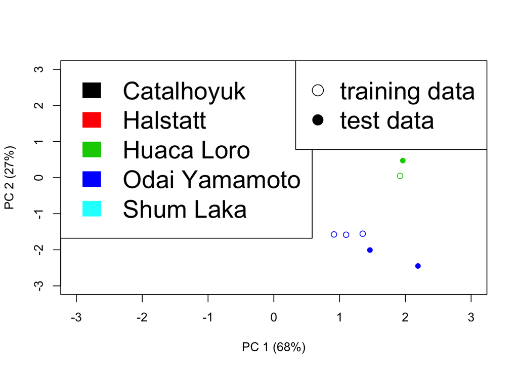

Be sure to check out [James, Witten, Hastie, and Tibshirani’s (2013) **An introduction to statistical learning with applications in R, 7th ed.**](http://www-bcf.usc.edu/~gareth/ISL/) to learn more!